# Midterm

## Visualizing and Summarizing the Data (15 points)

> *Use `group_by()` and `summarize()` to make a summary of the data here. The summary should be relevant to your research question*

```r
# Use the table1 package to make the table
label(data2$percentile2) <- "Birthweight category - percentile"
label(data2$age_preg_end_cat) <- "Age, end of pregnancy"
label(data2$race_ethnicity_cat2) <- "Race/Ethnicity"
label(data2$FPL.precat) <- "FPL"
label(data2$fullterm) <- "Full Term"
label(data2$bmi.pre.cat) <- "Maternal BMI category"

units(data2$age_preg_end_cat) <- "years"
units(data2$FPL.precat) <- "%"

## reorder variables to appear in the correct order
data2 <- data2 %>%
  mutate(payor_type_research_R = factor(payor_type_research_R, levels=c("Private", "Medicaid", "Medicare", "Uninsured")),
         lobw = factor(lobw, levels= c("Not low", "Low")),
         hibw = factor(hibw, levels= c("Not high", "High"))
         )

table1(~ percentile2 + race_ethnicity_cat2 + age_preg_end_cat + data2$bmi.pre.cat + FPL.precat + fullterm| payor_type_research_R, data=data2)
```

|  | Private (N=71392) | Medicaid (N=573215) | Medicare (N=2500) | Uninsured (N=62133) | Overall (N=709240) |
| --- | --- | --- | --- | --- | --- |
| Birthweight category - percentile |  |  |  |  |  |
| <10th | 5480 (7.7%) | 57988 (10.1%) | 432 (17.3%) | 5602 (9.0%) | 69502 (9.8%) |
| 10th-50th | 26275 (36.8%) | 234606 (40.9%) | 1018 (40.7%) | 25343 (40.8%) | 287242 (40.5%) |
| 50th-90th | 31235 (43.8%) | 224630 (39.2%) | 876 (35.0%) | 25057 (40.3%) | 281798 (39.7%) |
| >90th | 8402 (11.8%) | 55991 (9.8%) | 174 (7.0%) | 6131 (9.9%) | 70698 (10.0%) |
| Race/Ethnicity |  |  |  |  |  |
| 1. White | 39897 (55.9%) | 95325 (16.6%) | 1024 (41.0%) | 18858 (30.4%) | 155104 (21.9%) |
| 2. Black | 5811 (8.1%) | 54917 (9.6%) | 908 (36.3%) | 3158 (5.1%) | 64794 (9.1%) |
| 3. Hispanic | 18186 (25.5%) | 382090 (66.7%) | 389 (15.6%) | 36609 (58.9%) | 437274 (61.7%) |
| 4. AA/PI | 3483 (4.9%) | 23255 (4.1%) | 23 (0.9%) | 1520 (2.4%) | 28281 (4.0%) |
| 5. AI/AN | 361 (0.5%) | 2075 (0.4%) | 37 (1.5%) | 379 (0.6%) | 2852 (0.4%) |
| 6. Unknown/Multi/Other | 3654 (5.1%) | 15553 (2.7%) | 119 (4.8%) | 1609 (2.6%) | 20935 (3.0%) |
| Age, end of pregnancy (years) |  |  |  |  |  |
| 1. <18 | 618 (0.9%) | 13784 (2.4%) | 2 (0.1%) | 1189 (1.9%) | 15593 (2.2%) |
| 2. 18 to <20 | 1911 (2.7%) | 34550 (6.0%) | 44 (1.8%) | 3251 (5.2%) | 39756 (5.6%) |
| 3. 20 to <25 | 11492 (16.1%) | 142096 (24.8%) | 375 (15.0%) | 14990 (24.1%) | 168953 (23.8%) |
| 4. 25 to <30 | 21397 (30.0%) | 164499 (28.7%) | 719 (28.8%) | 18638 (30.0%) | 205253 (28.9%) |
| 5. 30 to <35 | 22284 (31.2%) | 128836 (22.5%) | 817 (32.7%) | 15109 (24.3%) | 167046 (23.6%) |
| 6. 35 to <40 | 11474 (16.1%) | 70487 (12.3%) | 418 (16.7%) | 7358 (11.8%) | 89737 (12.7%) |
| 7. 40+ | 2216 (3.1%) | 18963 (3.3%) | 125 (5.0%) | 1598 (2.6%) | 22902 (3.2%) |
| Maternal BMI category |  |  |  |  |  |
| 1. Underweight (<18.5) | 1215 (1.7%) | 11329 (2.0%) | 34 (1.4%) | 1059 (1.7%) | 13637 (1.9%) |
| 2. Normal/Healthy (18.5 to <25) | 29182 (40.9%) | 180820 (31.5%) | 757 (30.3%) | 21737 (35.0%) | 232496 (32.8%) |
| 3. Overweight (25 to <30) | 20392 (28.6%) | 184786 (32.2%) | 550 (22.0%) | 20487 (33.0%) | 226215 (31.9%) |
| 4. Obesity Class 1 (30 to <35) | 11825 (16.6%) | 114886 (20.0%) | 512 (20.5%) | 11559 (18.6%) | 138782 (19.6%) |
| 5. Obesity Class 2 (35 to <40) | 5266 (7.4%) | 50124 (8.7%) | 294 (11.8%) | 4778 (7.7%) | 60462 (8.5%) |
| 6. Obesity Class 3 (40+) | 3512 (4.9%) | 31270 (5.5%) | 353 (14.1%) | 2513 (4.0%) | 37648 (5.3%) |
| FPL (%) |  |  |  |  |  |
| 1. <138% FPL | 19071 (26.7%) | 331141 (57.8%) | 1521 (60.8%) | 33055 (53.2%) | 384788 (54.3%) |
| 2. >=138% FPL | 22470 (31.5%) | 68645 (12.0%) | 275 (11.0%) | 5713 (9.2%) | 97103 (13.7%) |
| 3. Missing | 29851 (41.8%) | 173429 (30.3%) | 704 (28.2%) | 23365 (37.6%) | 227349 (32.1%) |
| Full Term |  |  |  |  |  |
| Mean (SD) | 0.960 (0.196) | 0.945 (0.228) | 0.901 (0.299) | 0.947 (0.225) | 0.946 (0.225) |
| Median [Min, Max] | 1.00 [0, 1.00] | 1.00 [0, 1.00] | 1.00 [0, 1.00] | 1.00 [0, 1.00] | 1.00 [0, 1.00] |

```r
# logistic regression model with low birthweight as the outcome of interest

lobwXins <- glm(lobw ~ payor_type_research_R + race_ethnicity_cat2 + age_preg_end_cat + bmi.pre.cat + FPL.precat + gest.days, data = data2, family = "binomial")

summary(lobwXins)
```

```
##
## Call:
## glm(formula = lobw ~ payor_type_research_R + race_ethnicity_cat2 +
##     age_preg_end_cat + bmi.pre.cat + FPL.precat + gest.days,
##     family = "binomial", data = data2)
##
## Deviance Residuals:
##     Min       1Q   Median       3Q      Max
## -1.6014  -0.4827  -0.4187  -0.3631   2.6375
##
## Coefficients:
##                                              Estimate Std. Error z value
## (Intercept)                                 2.7048953  0.0891293  30.348
## payor_type_research_RMedicaid               0.1833027  0.0156647  11.702
## payor_type_research_RMedicare               0.7817984  0.0560327  13.953
## payor_type_research_RUninsured              0.1002604  0.0204241   4.909
## race_ethnicity_cat22. Black                 0.7222436  0.0149901  48.181
## race_ethnicity_cat23. Hispanic              0.2134972  0.0113809  18.759
## race_ethnicity_cat24. AA/PI                 0.4075773  0.0208241  19.572
## race_ethnicity_cat25. AI/AN                 0.0796160  0.0694579   1.146
## race_ethnicity_cat26. Unknown/Multi/Other   0.3081004  0.0246457  12.501
## age_preg_end_cat2. 18 to <20               -0.1688134  0.0268368  -6.290
## age_preg_end_cat3. 20 to <25               -0.2393229  0.0235506 -10.162
## age_preg_end_cat4. 25 to <30               -0.4303397  0.0236455 -18.200
## age_preg_end_cat5. 30 to <35               -0.5548840  0.0242006 -22.929
## age_preg_end_cat6. 35 to <40               -0.5328054  0.0256501 -20.772
## age_preg_end_cat7. 40+                     -0.3962252  0.0319392 -12.406
## bmi.pre.cat2. Normal/Healthy (18.5 to <25) -0.4210866  0.0230072 -18.302
## bmi.pre.cat3. Overweight (25 to <30)       -0.6999908  0.0234868 -29.804
## bmi.pre.cat4. Obesity Class 1 (30 to <35)  -0.9201133  0.0246029 -37.399
## bmi.pre.cat5. Obesity Class 2 (35 to <40)  -1.0739595  0.0276645 -38.821
## bmi.pre.cat6. Obesity Class 3 (40+)        -1.1461740  0.0306353 -37.413
## FPL.precat2. >=138% FPL                    -0.0287478  0.0129861  -2.214
## FPL.precat3. Missing                        0.0544036  0.0090316   6.024
## gest.days                                  -0.0156253  0.0002999 -52.107
##                                            Pr(>|z|)
## (Intercept)                                 < 2e-16 ***
## payor_type_research_RMedicaid               < 2e-16 ***
## payor_type_research_RMedicare               < 2e-16 ***
## payor_type_research_RUninsured             9.16e-07 ***
```

[output cut: 14 more lines]

```
## bmi.pre.cat5. Obesity Class 2 (35 to <40)   < 2e-16 ***
## bmi.pre.cat6. Obesity Class 3 (40+)         < 2e-16 ***
## FPL.precat2. >=138% FPL                      0.0268 *
## FPL.precat3. Missing                       1.70e-09 ***
## gest.days                                   < 2e-16 ***
## ---
## Signif. codes:  0 '***' 0.001 '**' 0.01 '*' 0.05 '.' 0.1 ' ' 1
##
## (Dispersion parameter for binomial family taken to be 1)
##
##     Null deviance: 454843  on 709239  degrees of freedom
## Residual deviance: 443130  on 709217  degrees of freedom
## AIC: 443176
##
## Number of Fisher Scoring iterations: 5
```

```r
exp(coef(lobwXins))
```

```
##                                (Intercept)
##                                 14.9527513
##              payor_type_research_RMedicaid
##                                  1.2011780
##              payor_type_research_RMedicare
##                                  2.1853990
##             payor_type_research_RUninsured
##                                  1.1054588
##                race_ethnicity_cat22. Black
##                                  2.0590477
##             race_ethnicity_cat23. Hispanic
##                                  1.2380000
##                race_ethnicity_cat24. AA/PI
##                                  1.5031716
##                race_ethnicity_cat25. AI/AN
##                                  1.0828712
##  race_ethnicity_cat26. Unknown/Multi/Other
##                                  1.3608375
##               age_preg_end_cat2. 18 to <20
##                                  0.8446665
##               age_preg_end_cat3. 20 to <25
##                                  0.7871607
##               age_preg_end_cat4. 25 to <30
##                                  0.6502882
##               age_preg_end_cat5. 30 to <35
##                                  0.5741389
##               age_preg_end_cat6. 35 to <40
##                                  0.5869560
##                     age_preg_end_cat7. 40+
##                                  0.6728551
## bmi.pre.cat2. Normal/Healthy (18.5 to <25)
##                                  0.6563333
##       bmi.pre.cat3. Overweight (25 to <30)
##                                  0.4965899
##  bmi.pre.cat4. Obesity Class 1 (30 to <35)
##                                  0.3984739
##  bmi.pre.cat5. Obesity Class 2 (35 to <40)
##                                  0.3416531
##        bmi.pre.cat6. Obesity Class 3 (40+)
##                                  0.3178505
##                    FPL.precat2. >=138% FPL
##                                  0.9716615
##                       FPL.precat3. Missing
##                                  1.0559107
##                                  gest.days
##                                  0.9844961
```

```r
# logistic regression model with high birthweight as the outcome of interest

hibwXins <- glm(hibw ~ payor_type_research_R + race_ethnicity_cat2 + age_preg_end_cat + bmi.pre.cat + FPL.precat + gest.days, data = data2, family = "binomial")

summary(hibwXins)
```

```
##
## Call:
## glm(formula = hibw ~ payor_type_research_R + race_ethnicity_cat2 +
##     age_preg_end_cat + bmi.pre.cat + FPL.precat + gest.days,
##     family = "binomial", data = data2)
##
## Deviance Residuals:
##     Min       1Q   Median       3Q      Max
## -0.8885  -0.4998  -0.4205  -0.3429   3.0309
##
## Coefficients:
##                                              Estimate Std. Error z value
## (Intercept)                                -7.2912406  0.1295600 -56.277
## payor_type_research_RMedicaid              -0.0840906  0.0136296  -6.170
## payor_type_research_RMedicare              -0.5977583  0.0804238  -7.433
## payor_type_research_RUninsured             -0.0988187  0.0184725  -5.349
## race_ethnicity_cat22. Black                -0.6678679  0.0177665 -37.591
## race_ethnicity_cat23. Hispanic             -0.2851271  0.0101131 -28.194
## race_ethnicity_cat24. AA/PI                -0.3626098  0.0241238 -15.031
## race_ethnicity_cat25. AI/AN                -0.4262671  0.0660154  -6.457
## race_ethnicity_cat26. Unknown/Multi/Other  -0.2525892  0.0250234 -10.094
## age_preg_end_cat2. 18 to <20               -0.0009903  0.0399847  -0.025
## age_preg_end_cat3. 20 to <25                0.1274526  0.0355126   3.589
## age_preg_end_cat4. 25 to <30                0.3270460  0.0351862   9.295
## age_preg_end_cat5. 30 to <35                0.4749380  0.0352908  13.458
## age_preg_end_cat6. 35 to <40                0.5274528  0.0359630  14.667
## age_preg_end_cat7. 40+                      0.5363214  0.0400932  13.377
## bmi.pre.cat2. Normal/Healthy (18.5 to <25)  0.7582999  0.0518279  14.631
## bmi.pre.cat3. Overweight (25 to <30)        1.1425421  0.0517624  22.073
## bmi.pre.cat4. Obesity Class 1 (30 to <35)   1.5193581  0.0519148  29.266
## bmi.pre.cat5. Obesity Class 2 (35 to <40)   1.7017578  0.0525321  32.395
## bmi.pre.cat6. Obesity Class 3 (40+)         1.9290072  0.0530185  36.384
## FPL.precat2. >=138% FPL                    -0.0094289  0.0122199  -0.772
## FPL.precat3. Missing                       -0.0047238  0.0091450  -0.517
## gest.days                                   0.0140274  0.0004084  34.347
##                                            Pr(>|z|)
## (Intercept)                                 < 2e-16 ***
## payor_type_research_RMedicaid              6.84e-10 ***
## payor_type_research_RMedicare              1.06e-13 ***
## payor_type_research_RUninsured             8.82e-08 ***
```

[output cut: 14 more lines]

```
## bmi.pre.cat5. Obesity Class 2 (35 to <40)   < 2e-16 ***
## bmi.pre.cat6. Obesity Class 3 (40+)         < 2e-16 ***
## FPL.precat2. >=138% FPL                    0.440350
## FPL.precat3. Missing                       0.605474
## gest.days                                   < 2e-16 ***
## ---
## Signif. codes:  0 '***' 0.001 '**' 0.01 '*' 0.05 '.' 0.1 ' ' 1
##
## (Dispersion parameter for binomial family taken to be 1)
##
##     Null deviance: 460130  on 709239  degrees of freedom
## Residual deviance: 445397  on 709217  degrees of freedom
## AIC: 445443
##
## Number of Fisher Scoring iterations: 6
```

```r
exp(coef(hibwXins))
```

```
##                                (Intercept)
##                               0.0006814821
##              payor_type_research_RMedicaid
##                               0.9193479931
##              payor_type_research_RMedicare
##                               0.5500433090
##             payor_type_research_RUninsured
##                               0.9059069501
##                race_ethnicity_cat22. Black
##                               0.5128007806
##             race_ethnicity_cat23. Hispanic
##                               0.7519186617
##                race_ethnicity_cat24. AA/PI
##                               0.6958578832
##                race_ethnicity_cat25. AI/AN
##                               0.6529418899
##  race_ethnicity_cat26. Unknown/Multi/Other
##                               0.7767869519
##               age_preg_end_cat2. 18 to <20
##                               0.9990102125
##               age_preg_end_cat3. 20 to <25
##                               1.1359310334
##               age_preg_end_cat4. 25 to <30
##                               1.3868652128
##               age_preg_end_cat5. 30 to <35
##                               1.6079144250
##               age_preg_end_cat6. 35 to <40
##                               1.6946103111
##                     age_preg_end_cat7. 40+
##                               1.7097059349
## bmi.pre.cat2. Normal/Healthy (18.5 to <25)
##                               2.1346439813
##       bmi.pre.cat3. Overweight (25 to <30)
##                               3.1347269122
##  bmi.pre.cat4. Obesity Class 1 (30 to <35)
##                               4.5692912299
##  bmi.pre.cat5. Obesity Class 2 (35 to <40)
##                               5.4835778698
##        bmi.pre.cat6. Obesity Class 3 (40+)
##                               6.8826740630
##                    FPL.precat2. >=138% FPL
##                               0.9906154515
##                       FPL.precat3. Missing
##                               0.9952873242
##                                  gest.days
##                               1.0141262895
```

> *What are your findings about the summary? Are they what you expected?*

My findings are that insurance type is associated with birthweight even after adjusting for gestational age, maternal age, race & ethnicity, BMI, and household income, Medicaid, Medicare, and no insurance are associated with higher odds of low birthweight, and lower odds of high birthweight. This is not unexpected, as insurance type is itself associated with a myriad of other factors, primarily social, which are not fully captured in study data.

> *Make at least two plots that help you answer your question on the transformed or summarized data. Use scales and/or labels to make each plot informative.*

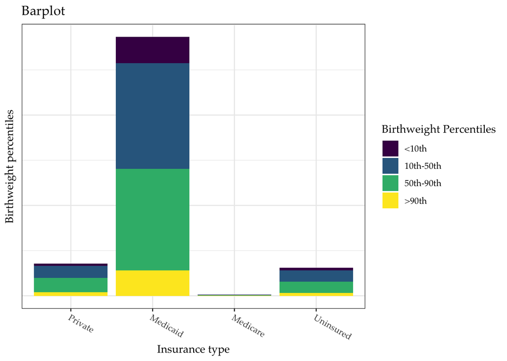

```r
# I was tragically disappointed by the lack of continuous birthweight data in this dataset, because it is listed in the data dictionary and I was planning to use it to make ridgeline density plots of birthweight by insurance type to visualize the relatve distribution. I remain crushed, because (in one scientist's humble opinion) the options for plots for categorical outcomes are not that fun. Nonetheless, I soldier on.

# A stacked barchart. I have removed the Y-axis labels because they were not informative, and I couldn't fgure out how to create a scale that would make them informative. I wanted to facet wrap them but then could not seem to find how we did that before.
ggplot(data = data2) +
  aes(x = payor_type_research_R) +
  geom_bar() +
  aes(fill = percentile2) +
  scale_fill_discrete(
    name = "Birthweight percentiles"
    ) +
  labs(x = "Insurance type",
       y = "Birthweight percentiles",
       title = "Barplot") +
  theme_bw() +
  theme(axis.text.x=element_text(
    angle = -30, hjust = 0), axis.ticks.x = ,
    axis.text.y=element_blank(),
      axis.ticks.y=element_blank()) +

  scale_fill_viridis_d(name = "Birthweight Percentiles") +
  theme(
    text = element_text(family = "Palatino"))
```

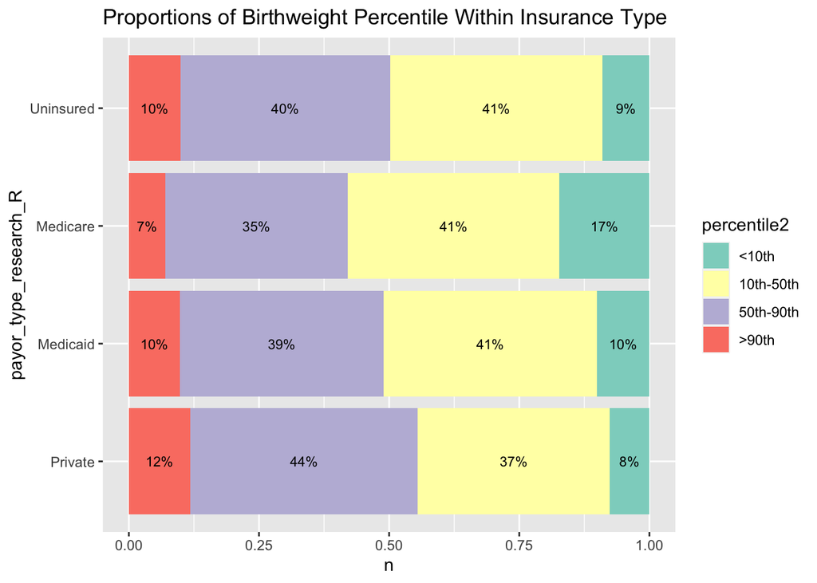

```r
# Because the previous bar chart really did little to convey anything and I could not figure out how to facet wrap it to make it useful, I decided to make one to show what percent each percentile of birthweight category is within each insurance type.
# First I need to make row percentages of birthweight percentile category
row_pct <- data2 %>%
  group_by(payor_type_research_R) %>%
  count(percentile2) %>%
  mutate(percent = (n/sum(n)) * 100,
         label = sprintf("%0.0f%%", percent))

ggplot(data2) +
  aes(x=payor_type_research_R,fill=percentile2) +
  geom_bar(position="fill") +
  geom_text(data=row_pct, aes(y=n,label=label),position=position_fill(vjust = 0.5), size = 3) +
  scale_fill_brewer(palette="Set3") +
  coord_flip() +
  ggtitle("Proportions of Birthweight Percentile Within Insurance Type")
```

## Final Summary (10 points)

> *Summarize your research question and findings below.*

> *Are your findings what you expected? Why or Why not?*

The associations themselves are not unexpected, as insurance type is itself associated with a myriad of other factors, primarily social, which are not fully captured in study data. However, because I adjusted for the most obvious potential confounders for which we had data, in particular income, race, and gestational age, I was surprised that these associations remained as strong as they are. The most curious finding, for me, was actually for one of the adjustment variables - I was not expecting to find that %FPL was not significantly associated with birthweights in the 90th percentile even with the other variables included in the model. assuming I coded all my variables correctly, these findings point toward a juicy avenue of future research.